# NCAAF Division 1-A and 1-AA Awards Analysis

3/20/2020

### Purpose

Ensure that all suitable NCAAF talent is examined and assessed

### Analytical questions

- Who are the potential players that are likely to enter the NFL based on their NCAA awards?
  - How do you determine the most significant awards?

### Data Input

- Awardees between 1933-2018 (analysis used up to year 2015 since players might not enter the NFL right away after some awards like Freshmen of the Year awards.)
- There is missing data. For example, J.J. Watt received the Deacon Jones Player of the Year award in 2015 but it is not captured in the data set.

### Approach

1. Determine the total number of awards that were given out by each award.
2. Determine how many of those awards resulted in the player entering the NFL.
3. Identify the awards that led to at least **90%** of their awardees entering the NFL. If **90%** isn’t a wide enough net then it can be decreased.
4. Identify the 2015 awardees that entered the NFL.
5. Identify the awardees that might potentially enter the NFL through the 2020 draft. (I don’t have data for this.)

### Key Insights

1. There are **50** awards which resulted in **100%** of the awardees entering the NFL draft. There are **5** more awards, which resulted in at least **90%** of the awardees entering the NFL draft.
2. NCAAF players who received these top awards from several years ago should also be considered since some eventually entered the NFL.

### Chart Explanation

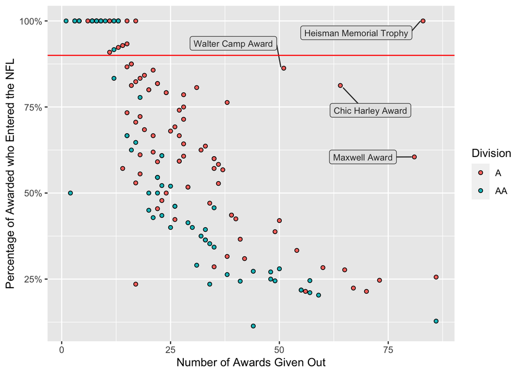

### Awards Resulting in the most NFL Players

The table depicts all of the awards that have resulted in at least **90%** of awardees entering the NFL draft.

| id | Name of Award | Scope | Total Number of Awards | % Entered NFL |
| --- | --- | --- | --- | --- |
| 1 | Heisman Memorial Trophy | National | 83 | 100% |
| 2 | Offensive Lineman of the Year | Big 12 | 17 | 100% |
| 3 | Manning Award | National | 15 | 100% |
| 4 | Defensive Lineman of the Year | Big 12 | 13 | 100% |
| 5 | Ozzie Newsome Award | National | 13 | 100% |
| 6 | Defensive Player of the Year | Colonial | 13 | 100% |
| 7 | Defensive Player of the Year | SWAC | 13 | 100% |
| 8 | Offensive Player of the Year | SWAC | 13 | 100% |
| 9 | Scholar-Athlete of the Year | Pac 12 | 12 | 100% |
| 10 | Newcomer of the Year | SWAC | 12 | 100% |
| 11 | Special Teams Player of the Year | Colonial | 12 | 100% |
| 12 | Most Valuable Player | C-USA | 11 | 100% |
| 13 | Newcomer of the Year | C-USA | 11 | 100% |
| 14 | Defensive Rookie of the Year | Colonial | 10 | 100% |
| 15 | Burlsworth Trophy | National | 9 | 100% |
| 16 | Offensive Rookie of the Year | ACC | 9 | 100% |
| 17 | Bakken-Andersen Kicker of the Year | Big Ten | 9 | 100% |
| 18 | Offensive Freshman of the Year | Pac 12 | 9 | 100% |
| 19 | Freshman of the Year | SWAC | 9 | 100% |
| 20 | Offensive Rookie of the Year | Colonial | 9 | 100% |
| 21 | Vlade Award | National | 8 | 100% |
| 22 | Paul Hornung Award | National | 8 | 100% |
| 23 | Defensive Freshman of the Year | Pac 12 | 8 | 100% |
| 24 | Butkus-Fitzgerald Linebacker of the Year | Big Ten | 8 | 100% |
| 25 | Kwalick-Clark Tight End of the Year | Big Ten | 8 | 100% |
| 26 | Griese-Brees Quarterback of the Year | Big Ten | 8 | 100% |
| 27 | Tatum-Woodson Defensive Back of the Year | Big Ten | 8 | 100% |
| 28 | Freshman Defensive Player of the Year | Pioneer | 8 | 100% |
| 29 | Freshman Offensive Player of the Year | Pioneer | 8 | 100% |
| 30 | Bushnell Cup Trophy (Def.) | Ivy | 8 | 100% |
| 31 | Bushnell Cup Trophy (Off.) | Ivy | 8 | 100% |
| 32 | Eddleman-Fields Punter of the Year | Big Ten | 7 | 100% |
| 33 | Ameche-Dayne Running Back of the Year | Big Ten | 7 | 100% |
| 34 | Richter-Howard Receiver of the Year | Big Ten | 7 | 100% |
| 35 | Scholar-Athlete of the Year | Big 12 | 7 | 100% |
| 36 | Defensive Player of the Year | AAC | 7 | 100% |
| 37 | Offensive Lineman of the Year | Southland | 7 | 100% |
| 38 | Scholar-Athlete of the Year | Pioneer | 7 | 100% |
| 39 | FCS Player of the Year | National | 7 | 100% |
| 40 | Chuck Boone Leadership Award | Colonial | 7 | 100% |
| 41 | Special Teams Player of the Year | AAC | 6 | 100% |
| 42 | Offensive Player of the Year | AAC | 4 | 100% |
| 43 | Rookie of the Year | AAC | 4 | 100% |
| 44 | Special Teams Player of the Year | Big South | 4 | 100% |
| 45 | Special Teams Player of the Year | Pioneer | 4 | 100% |
| 46 | Jerry Rice Award | National | 4 | 100% |
| 47 | Rodgers-Dwight Return Specialist of the Year | Big Ten | 3 | 100% |
| 48 | Deacon Jones Award | National | 3 | 100% |
| 49 | Freshman of the Year | Big Sky | 3 | 100% |
| 50 | Pinnacle Award | SOCON | 1 | 100% |
| 51 | Special Teams Player of the Year | SEC | 15 | 93% |
| 52 | Wuerffel Trophy | National | 14 | 92% |
| 53 | Special Teams Player of the Year | MWC | 13 | 92% |
| 54 | Offensive Player of the Year | Colonial | 12 | 91% |
| 55 | Defensive Rookie of the Year | ACC | 11 | 90% |

### 2015 Awardees

| id | Name of Award | Scope | 2015 Awardee | Entered NFL? | Year Entered NFL |
| --- | --- | --- | --- | --- | --- |
| 1 | Heisman Memorial Trophy | National | HENRY, DERRICK | yes | 2016 |
| 2 | Offensive Lineman of the Year | Big 12 | DRANGO, SPENCER | yes | 2016 |
| 3 | Manning Award | National | WATSON, DESHAUN | yes | 2017 |
| 4 | Defensive Lineman of the Year | Big 12 | BILLINGS, ANDREW | yes | 2016 |
| 5 | Ozzie Newsome Award | National | BUTT, JAKE | yes | 2017 |
| 6 | Defensive Player of the Year | Colonial | HOUSTON-CARSON, DEANDRE | yes | 2016 |
| 6 | Defensive Player of the Year | Colonial | OCHI, VICTOR | yes | 2016 |
| 7 | Defensive Player of the Year | SWAC | BERRY, KOURTNEY | yes | 2017 |
| 8 | Offensive Player of the Year | SWAC | WILLIAMS, JOHNATHAN | yes | 2017 |
| 9 | Scholar-Athlete of the Year | Pac 12 | BERCOVICI, MIKE | yes | 2016 |
| 10 | Newcomer of the Year | SWAC | WARFORD, MARQUISE | yes | 2019 |
| 11 | Special Teams Player of the Year | Colonial | DEDMON, DEVONTE | yes | 2019 |
| 12 | Most Valuable Player | C-USA | DOUGHTY, BRANDON | yes | 2016 |
| 13 | Newcomer of the Year | C-USA | DRISKEL, JEFF | yes | 2016 |
| 14 | Defensive Rookie of the Year | Colonial | COX, JULIAN | yes | 2019 |
| 14 | Defensive Rookie of the Year | Colonial | TEDDER, CHRIS | yes | 2019 |
| 15 | Burlsworth Trophy | National | MAYFIELD, BAKER | yes | 2018 |
| 16 | Offensive Rookie of the Year | ACC | OLLISON, QADREE | yes | 2019 |
| 17 | Bakken-Andersen Kicker of the Year | Big Ten | OAKES, GRIFFIN | yes | 2018 |
| 18 | Offensive Freshman of the Year | Pac 12 | ROSEN, JOSH | yes | 2018 |
| 19 | Freshman of the Year | SWAC | CHAMBERS, BOOKER | yes | 2019 |
| 20 | Offensive Rookie of the Year | Colonial | BEDNARCZYK, ZACH | yes | 2019 |
| 20 | Offensive Rookie of the Year | Colonial | JEFFERSON, THOMAS | yes | 2019 |
| 21 | Vlade Award | National | SCHNEIDER, AIDEN | yes | 2018 |
| 22 | Paul Hornung Award | National | MCCAFFREY, CHRISTIAN | yes | 2017 |
| 23 | Defensive Freshman of the Year | Pac 12 | SMITH, CAMERON | yes | 2019 |
| 24 | Butkus-Fitzgerald Linebacker of the Year | Big Ten | SCHOBERT, JOE | yes | 2016 |
| 25 | Kwalick-Clark Tight End of the Year | Big Ten | BUTT, JAKE | yes | 2017 |
| 26 | Griese-Brees Quarterback of the Year | Big Ten | COOK, CONNOR | yes | 2016 |
| 27 | Tatum-Woodson Defensive Back of the Year | Big Ten | KING, DESMOND | yes | 2017 |
| 28 | Freshman Defensive Player of the Year | Pioneer | RYAN, JACK | yes | 2019 |
| 29 | Freshman Offensive Player of the Year | Pioneer | LAWRENCE, ANTHONY | yes | 2019 |
| 30 | Bushnell Cup Trophy (Def.) | Ivy | DRAKE, TYLER | yes | 2016 |
| 31 | Bushnell Cup Trophy (Off.) | Ivy | HOSCH, SCOTT | yes | 2016 |
| 32 | Eddleman-Fields Punter of the Year | Big Ten | FOLTZ, SAM | yes | 2017 |
| 33 | Ameche-Dayne Running Back of the Year | Big Ten | ELLIOTT, EZEKIEL | yes | 2016 |
| 34 | Richter-Howard Receiver of the Year | Big Ten | BURBRIDGE, AARON | yes | 2016 |
| 35 | Scholar-Athlete of the Year | Big 12 | DARLINGTON, TY | yes | 2016 |
| 36 | Defensive Player of the Year | AAC | MATAKEVICH, TYLER | yes | 2016 |
| 37 | Offensive Lineman of the Year | Southland | JACKSON, DONALD | yes | 2016 |
| 38 | Scholar-Athlete of the Year | Pioneer | BEASCHLER, CHRISTOPHER | yes | 2017 |
| 38 | Scholar-Athlete of the Year | Pioneer | SHILTZ, MATT | yes | 2016 |
| 39 | FCS Player of the Year | National | JENKINS, ELI | yes | 2017 |
| 40 | Chuck Boone Leadership Award | Colonial | PRUS, JAKE | yes | 2016 |
| 41 | Special Teams Player of the Year | AAC | ELLIOTT, JAKE | yes | 2017 |
| 42 | Offensive Player of the Year | AAC | REYNOLDS, KEENAN | yes | 2016 |
| 43 | Rookie of the Year | AAC | SMITH, TRE’QUAN | yes | 2018 |
| 44 | Special Teams Player of the Year | Big South | BROWN, DEVIN | yes | 2017 |
| 45 | Special Teams Player of the Year | Pioneer | DIBALSAMO, GUY | yes | 2017 |
| 45 | Special Teams Player of the Year | Pioneer | KACZKOWSKI, NICK | yes | 2016 |
| 46 | Jerry Rice Award | National | NA | NA | NA |
| 47 | Rodgers-Dwight Return Specialist of the Year | Big Ten | LIKELY, WILLIAM | yes | 2017 |
| 48 | Deacon Jones Award | National | NA | NA | NA |
| 49 | Freshman of the Year | Big Sky | SANTIAGO, JOHN | yes | 2019 |
| 50 | Pinnacle Award | SOCON | NA | NA | NA |
| 51 | Special Teams Player of the Year | SEC | BERRY, EVAN | yes | 2018 |
| 52 | Wuerffel Trophy | National | DARLINGTON, TY | yes | 2016 |
| 53 | Special Teams Player of the Year | MWC | PENNY, RASHAAD | yes | 2018 |
| 54 | Offensive Player of the Year | Colonial | LEE, VAD | yes | 2016 |
| 55 | Defensive Rookie of the Year | ACC | WHITEHEAD, JORDAN | yes | 2018 |